# Assignment 3

## x-y Plot with Leverage

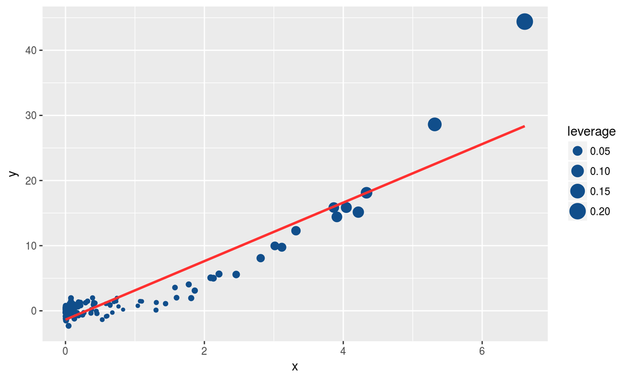

## Simulating OLS Estimators

## OLS Estimators Under Homoskedasticity

Table 1: OLS Estimates Under Homoskedasticity

|  | Mean | S.D. | Reject |
| --- | --- | --- | --- |
| Beta | -0.001 | 0.615 | NaN |
| SE Conventional | 0.604 | 0.081 | 0.053 |
| SE Heteroskedasticity | 0.659 | 0.310 | 0.102 |
| SE Unfeasible | 0.609 | 0.000 | 0.044 |

Here we see that using heteroskedastic standard errors are only slightly larger and cause us to over-reject the null (comparing 0.102 to 0.044 and 0.053). In the figure, this is evident by the slightly fatter tails for the robust standard errors.

## OLS Estimators Under Heteroskedasticity

Table 2: OLS Estimates Under Heteroskedasticity

|  | Mean | S.D. | Reject |
| --- | --- | --- | --- |
| Beta | 0.001 | 0.590 | NaN |
| SE Conventional | 0.331 | 0.052 | 0.258 |
| SE Heteroskedasticity | 0.630 | 0.324 | 0.122 |
| SE Unfeasible | 0.451 | 0.000 | 0.115 |

## Figures

## Homoskedasticity

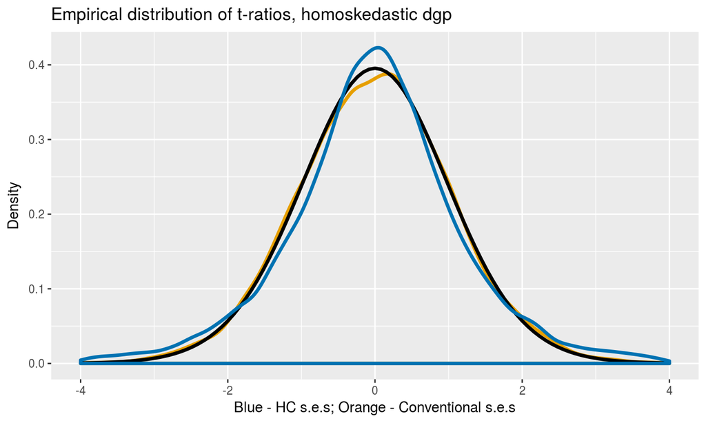

## Heteroskedasticity

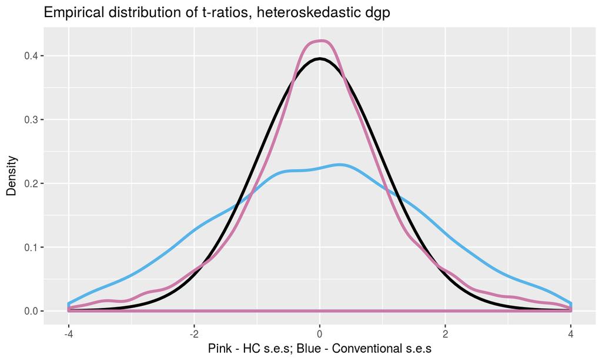

## Conclusion

We see that there is a very small bias when using heteroskedastic robust standard errors when the data is homoskedastic. However, we run into a serious problem when using conventional standard errors when the data is heteroskedastic as the bias will be very large.

Although controlling for heteroskedasticity significantly reduces the bias when heteroskadisticity is present, the estimates will still be biased *relative* to correctly estimating standard errors under homoskedasticity. This is seen by comparing the difference between the mean heteroskedastic standard error in table 2 and the unfeasible one (0.179) to the difference between the mean homoskedastic standard error in table 1 to the unfeasbile one (0.005).